# Schistocerca ceratiola

Heath Blackmon

3/7/2018

## Introduction

Lets look at a dataset inspired by one that one of your peers is dealing with in their own research. This dataset illustrates some very realistic challenges that you might face as you begin to generate your own data.

The data in this experiment are from a machine that is attempting to detect a specific chemical. We test 6 control samples and 7, 10, and 10 experimental samples. Unfortunately the machine that we are using has quite high variance in estimates and occasionally the sample prep can also lead to false negatives.

## Visualize your data

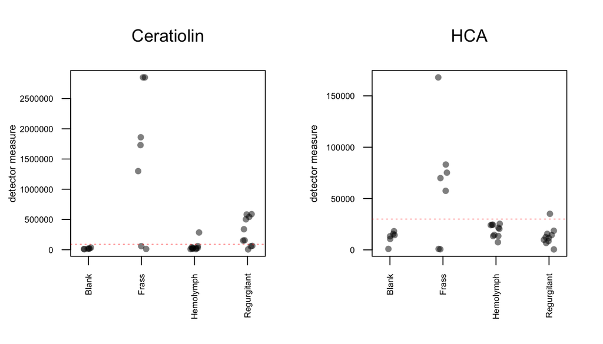

```r
par(mfcol=c(1,2))
dat <- read.csv("Ceratiola samples.csv")

stripchart(dat$Ceratiolin~dat$Sample,
           vertical=T,
           pch=16,
           method="jitter",
           col=rgb(0,0,0,.5),
           ylab="detector measure", cex.lab = .7,
           main="Ceratiolin", cex.axis=.6, las=2)
abline(h=90000,
       col=rgb(1,0,0,.5),
       lty=3)
stripchart(dat$HCA~dat$Sample,
           vertical=T,
           pch=16,
           method="jitter",
           col=rgb(0,0,0,.5),
           ylab="detector measure",  cex.lab = .7,
           main="HCA", cex.axis=.6, las=2)
abline(h=30000,
       col=rgb(1,0,0,.5),
       lty=3)
```

What are the options?

Problems with an ANOVA approach?

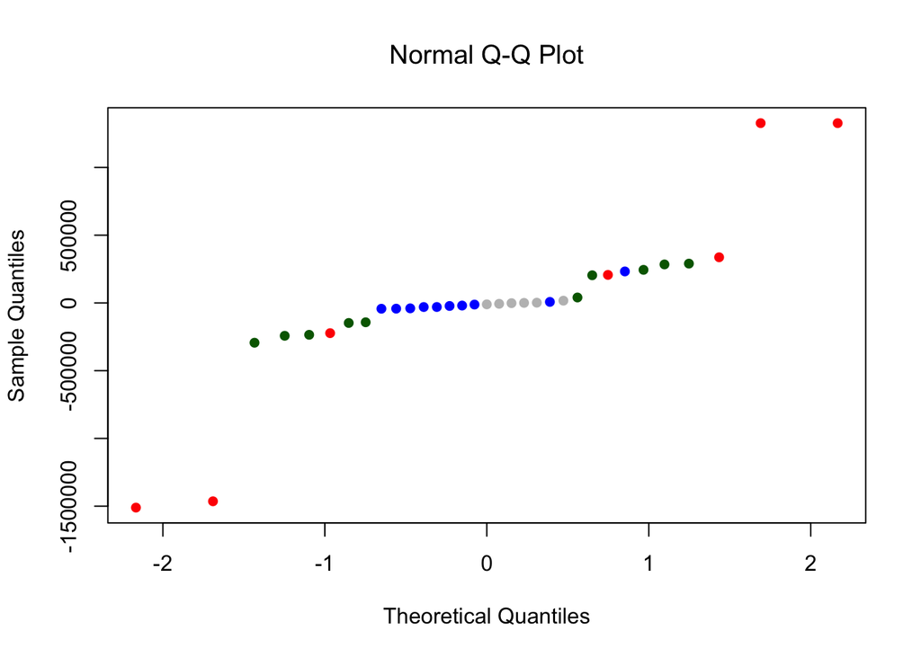

```r
fit.c <- lm(dat$Ceratiolin~dat$Sample)
cols <- c(rep("darkgreen", 10),
          rep("blue", 10),
          rep("red", 7),
          rep("gray", 6))
qqnorm(fit.c$residuals, col=cols, pch=16)
```

```r
library(car)
leveneTest(dat$Ceratiolin~dat$Sample)
```

```
## Levene's Test for Homogeneity of Variance (center = median)
##       Df F value  Pr(>F)
## group  3  11.242 4.6e-05 ***
##       29
## ---
## Signif. codes:  0 '***' 0.001 '**' 0.01 '*' 0.05 '.' 0.1 ' ' 1
```

So the data is definitely heteroscedastic. Lets check to see what the group variances are. Generally a linear model is fairly robust to heterogeneity of variance so long as the maximum difference is less than 4 fold.

```r
vars <- c()
vars[1] <- var(dat$Ceratiolin[dat$Sample=="Blank"])
vars[2]  <- var(dat$Ceratiolin[dat$Sample=="Frass"])
vars[3]  <- var(dat$Ceratiolin[dat$Sample=="Regurgitant"])
vars[4]  <- var(dat$Ceratiolin[dat$Sample=="Hemolymph"])
max(vars)/min(vars)
```

```
## [1] 15659.63
```

So two options Kruskal-Wallis and permutation lets compare the two.

```r
kruskal.test(dat$Ceratiolin~dat$Sample)
```

```
##
##  Kruskal-Wallis rank sum test
##
## data:  dat$Ceratiolin by dat$Sample
## Kruskal-Wallis chi-squared = 14.772, df = 3, p-value = 0.002022
```

```r
library(dunn.test)
dunn.test(x=dat$Ceratiolin, g=dat$Sample)
```

```
##   Kruskal-Wallis rank sum test
##
## data: x and group
## Kruskal-Wallis chi-squared = 14.772, df = 3, p-value = 0
##
##
##                            Comparison of x by group
##                                 (No adjustment)
## Col Mean-|
## Row Mean |      Blank      Frass   Hemolymp
## ---------+---------------------------------
##    Frass |  -3.235575
##          |    0.0006*
## Hemolymp |  -0.807811   2.806291
##          |     0.2096    0.0025*
## Regurgit |  -2.590338   0.938428  -2.058284
##          |    0.0048*     0.1740    0.0198*
##
## alpha = 0.05
## Reject Ho if p <= alpha/2
```

Permutation

```r
frass <- mean(dat$Ceratiolin[dat$Sample=="Frass"])
regur <- mean(dat$Ceratiolin[dat$Sample=="Regurgitant"])
hemol <- mean(dat$Ceratiolin[dat$Sample=="Hemolymph"])

#Hemolymph
pop <- c(dat$Ceratiolin[dat$Sample=="Hemolymph"],
         dat$Ceratiolin[dat$Sample=="Blank"])
null.samp <- c()
for(i in 1:10000){
  null.samp[i] <- mean(sample(pop, 10))
}
p.hemol <- sum(null.samp >= hemol)/10000

#Regurgitant
pop <- c(dat$Ceratiolin[dat$Sample=="Regurgitant"],
         dat$Ceratiolin[dat$Sample=="Blank"])
null.samp <- c()
for(i in 1:10000){
  null.samp[i] <- mean(sample(pop, 10))
}
p.regurg <- sum(null.samp >= regur)/10000

#frass
pop <- c(dat$Ceratiolin[dat$Sample=="Frass"],
         dat$Ceratiolin[dat$Sample=="Blank"])
null.samp <- c()
for(i in 1:10000){
  null.samp[i] <- mean(sample(pop, 7))
}
p.frass <- sum(null.samp >= frass)/10000
```

```r
p.regurg
```

```
## [1] 0.001
```

```r
p.frass
```

```
## [1] 0.0037
```

```r
p.hemol
```

```
## [1] 0.084
```

This actually does a good job of exhibitiing a weakness of the permutation test